# nor_titanic

Introduction.

I'll do a HTML write up later, so this is an informal guide to what I hope to do and what code I'm writing. The 'question' phase will be covered in the HTML document, as well as an overview of the 'wrangle' and 'explore' phases, and the 'draw conclusions' and 'communicate' phases. The bulk of the 'wrangle, and 'explore' work will be outlined in this document.

I'm not too familar with the Titanic disaster, so I'm not really sure what questions I should be asking. I've heard that it was rumoured that steerage class passengers were locked in their cabins, so it might be interesting to see what the survivorship ratio was by ticket class. I've also heard that because of the 'women and children first' rule, some men were mocked for getting into the lifeboats. It might be interesting to divide the survivors into three groups (men, women and children) and see what the survivorship ratios are for those groups. Lastly, I plan to divide the passengers by age. This is mostly an excercise to divide the survivors into bins and see what the ratios were. So in summary, the questions I plan to ask are :

What are the survivorship ratios by passenger class?

What are the survivorship ratios for men, women, and children?

What are the survivorship ratios by age?

Wrangling and exploring.

The dataset is relatively small so it's possible to view it as a spreadsheet and draw some conclussions. Every passenger has a numeric passenger class attribute. I think I'll only be using this once, so it might be practical to leave this as a string, but I'll convert this to an integer as practice. In answering the first question, I can use the entire dataset, but I suspect it may be helpfull to create a dataset of survivors too.

```python
#Read the passenger data and store in a dataframe

import pandas as pd

passengers_full = pd.read_csv('titanic-data.csv')
```

```python
#Print off and examine some passenger data.  No need to run this cell later.


#print (passengers_full.head(80))
```

It turns out that the read_csv() function interprets dtypes, so there's no need to use the to_numeric() fuction to change the Pclass or Age columns to numeric types. It's worth noting that ages are stored as floats and infants are represented with decimal approximations. I'm going to leave this as is to preserve the original data, and only convert to integers for plotting\analysis after the data is extracted.

Seveal colums have inconsistencies; the 'Cabin' column for example. Not every passenger has a cabin attribute, some have one cabin and some have several. I don't need this column or many others for my analysis, so I'm going to drop these from the dataframe.

```python
passengers = passengers_full.drop(['PassengerId', 'Name', 'SibSp', 'Parch', 'Ticket', 'Fare', 'Cabin', 'Embarked'], axis=1)

#print (passengers.head(20))
```

At this point the 'passengers' dataframe just has one column with inconsistencies; the 'Age' column. As stated above, I'm not going to try and resolve this, but work with sample dataframes instead.

Next, I'll seperate the passengers by creating a survivors group and groups for passengers and survivors with age attributes.

```python
#Create a dataframe of passengers who survived

survivors = passengers[passengers['Survived'] == 1]

print (len(survivors))
#print (survivors.head(20))
```

```
342
```

```python
#Create a dataframe of passengers who survived and have an age attribute
#could also do this using passengers.dropna() since this is the only column left with missing values

passengers_with_age = passengers[passengers['Age'] >= 0.0]

print (len(passengers_with_age))
#print (passengers_with_age.head(20))
```

```
714
```

```python
#Create a dataframe of passengers who survived and have an age attribute

survivors_with_age = survivors[survivors['Age'] >= 0.0]

print (len(survivors_with_age))
#print (survivors_with_age.head(20))
```

```
290
```

At this point we have a survivors dataframe that gives us a population of 342 surviving passengers out of 891, a dataframe with a sample of 714 passengers with an age attribute, and a dataframe with a sample of 290 surviving passengers with an age attribute.

Next, I'll try to get the data to answer the first question. I think it'd be impractical to seperate the data further; I think counts of the passenger classes will be enough.

Note : Any variables that are derived from the complete 'passengers' or 'survivors' dataframes can be identified by the '_pop' in the variable name.

```python
#Get counts of passengers in different classes, then survivors.

def count_classes(my_dataframe):

    first_class_count = my_dataframe['Pclass'][(my_dataframe['Pclass']==1)].sum()
    second_class_count = (my_dataframe['Pclass'][(my_dataframe['Pclass']==2)].sum())/2
    third_class_count = (my_dataframe['Pclass'][(my_dataframe['Pclass']==3)].sum())/3

    return first_class_count, second_class_count, third_class_count


total_first_class_count_pop, total_second_class_count_pop, total_third_class_count_pop = count_classes(passengers)
surviving_first_class_count_pop, surviving_second_class_count_pop, surviving_third_class_count_pop = count_classes(survivors)



print 'Total number of passengers in first class : ', total_first_class_count_pop
print 'Total number of passengers in second class : ', total_second_class_count_pop
print 'Total number of passengers in third class : ', total_third_class_count_pop
print 'Total number of survivors in first class : ', surviving_first_class_count_pop
print 'Total number of survivors in second class : ', surviving_second_class_count_pop
print 'Total number of survivors in third class : ', surviving_third_class_count_pop
```

```
Total number of passengers in first class :  216
Total number of passengers in second class :  184
Total number of passengers in third class :  491
Total number of survivors in first class :  136
Total number of survivors in second class :  87
Total number of survivors in third class :  119
```

At this point we know 342 passengers out of 891 survived; about 38%. Out of 216 first class passengers, 136 survived; about 63%. For second class there was 87 survivors out of 184; about 47%. When we look at the third class passengers, only 119 out of 491 survived; about 24%. It seems that for whatever reason a passengers chances of survival dropped with their ticket class.

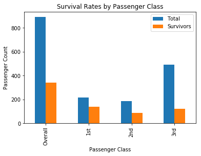

```python
#A little inefficient to create a dataframe at this point, but I think it's more readable this way.

%matplotlib inline

classes_dict = {'Total' : pd.Series([891, total_first_class_count_pop, total_second_class_count_pop, total_third_class_count_pop], index=['Overall', '1st', '2nd', '3rd']),
               'Survivors' : pd.Series([342, surviving_first_class_count_pop, surviving_second_class_count_pop, surviving_third_class_count_pop], index=['Overall', '1st', '2nd', '3rd'])}

classes_frame = pd.DataFrame(classes_dict, columns=['Total', 'Survivors'])


classes_plot = classes_frame.plot.bar(title='Survival Rates by Passenger Class');
classes_plot.set_xlabel("Passenger Class")
classes_plot.set_ylabel("Passenger Count")
```

```python
#Generate chi-square values for survivorship by passenger class
import numpy as np
from scipy.stats import chi2_contingency

non_surviving_first_class_count_pop = total_first_class_count_pop - surviving_first_class_count_pop
non_surviving_second_class_count_pop = total_second_class_count_pop - surviving_second_class_count_pop
non_surviving_third_class_count_pop = total_third_class_count_pop - surviving_third_class_count_pop


observed_values_pop = np.array([[surviving_first_class_count_pop, surviving_second_class_count_pop, surviving_third_class_count_pop],
                                [non_surviving_first_class_count_pop, non_surviving_second_class_count_pop, non_surviving_third_class_count_pop]])


chi2_pop, p_value_pop, dof_pop, expected_values_pop = chi2_contingency(observed_values_pop)

print chi2_pop
print p_value_pop
print dof_pop
```

```
102.888988757
4.5492517113e-23
2
```

From this point on I'll be working with the sample dataframes that include an age attribute. First, I'll examine the numbers of men, women and children that survived. I'll be using the convention that a child is anyone under the age of 18, though this may not have been the case at the time.

```python
#Get type of passengers, then survivors.

def count_types(my_dataframe, adult_age = 18.0):

    male_count = len(my_dataframe['Sex'][(my_dataframe['Sex']=='male') & (my_dataframe['Age']>=adult_age) ])
    female_count = len(my_dataframe['Sex'][(my_dataframe['Sex']=='female') & (my_dataframe['Age']>=adult_age) ])
    child_count = len(my_dataframe['Sex'][(my_dataframe['Age'] < adult_age) ])

    return male_count, female_count, child_count


total_male_count, total_female_count, total_child_count = count_types(passengers_with_age)
surviving_male_count, surviving_female_count, surviving_child_count = count_types(survivors_with_age)


print 'Total number of male passengers in sample : ', total_male_count
print 'Total number of female passengers in sample : ', total_female_count
print 'Total number of child passengers in sample : ', total_child_count
print 'Total number of male survivors in sample : ', surviving_male_count
print 'Total number of female survivors in sample : ', surviving_female_count
print 'Total number of child survivors in sample : ', surviving_child_count
```

```
Total number of male passengers in sample :  395
Total number of female passengers in sample :  206
Total number of child passengers in sample :  113
Total number of male survivors in sample :  70
Total number of female survivors in sample :  159
Total number of child survivors in sample :  61
```

So at this point out of a roughly 38% overall survival rate, we can see the survival rate for male passengers is only about 18% - less than half. Women had the highest survival rate at around 77%. Children had around a 54% survival rate.

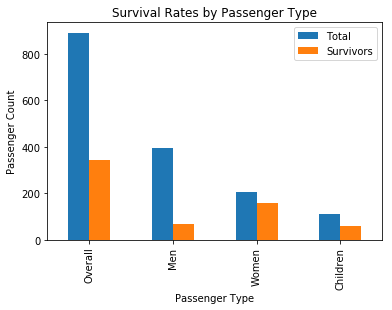

```python
#Another dataframe created at this point, but I think it's more readable this way.

types_dict = {'Total' : pd.Series([891, total_male_count, total_female_count, total_child_count], index=['Overall', 'Men', 'Women', 'Children']),
               'Survivors' : pd.Series([342, surviving_male_count, surviving_female_count, surviving_child_count], index=['Overall', 'Men', 'Women', 'Children'])}

types_frame = pd.DataFrame(types_dict, columns=['Total', 'Survivors'])

types_plot = types_frame.plot.bar(title='Survival Rates by Passenger Type');
types_plot.set_xlabel("Passenger Type")
types_plot.set_ylabel("Passenger Count")
```

```python
#Generate chi-square values for survivorship by passenger type
import numpy as np
from scipy.stats import chi2_contingency

non_surviving_male_count = total_male_count - surviving_male_count
non_surviving_female_count = total_female_count - surviving_female_count
non_surviving_child_count = total_child_count - surviving_child_count


t_observed_values = np.array([[surviving_male_count, surviving_female_count, surviving_child_count],
                                [non_surviving_male_count, non_surviving_female_count, non_surviving_child_count]])


t_chi2, t_p_value, t_dof, t_expected_values = chi2_contingency(t_observed_values)

print t_chi2
print t_p_value
print t_dof
```

```
208.422867885
5.51504788509e-46
2
```

```
Total number of male passengers in sample :  413
Total number of female passengers in sample :  218
Total number of child passengers in sample :  83
Total number of male survivors in sample :  72
Total number of female survivors in sample :  169
Total number of child survivors in sample :  49
```

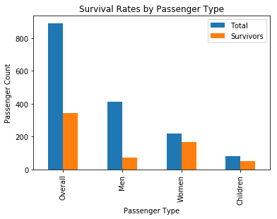

```python
#I'm going to use this cell to play around with the adult_age a bit.  No need to run this cell later
#Also using different variable names so if this is run, it won't affect subsequent cells.

unlucky_age = 16.0

n_total_male_count, n_total_female_count, n_total_child_count = count_types(passengers_with_age, unlucky_age)
n_surviving_male_count, n_surviving_female_count, n_surviving_child_count = count_types(survivors_with_age, unlucky_age)

print 'Total number of male passengers in sample : ', n_total_male_count
print 'Total number of female passengers in sample : ', n_total_female_count
print 'Total number of child passengers in sample : ', n_total_child_count
print 'Total number of male survivors in sample : ', n_surviving_male_count
print 'Total number of female survivors in sample : ', n_surviving_female_count
print 'Total number of child survivors in sample : ', n_surviving_child_count

n_types_dict = {'Total' : pd.Series([891, n_total_male_count, n_total_female_count, n_total_child_count], index=['Overall', 'Men', 'Women', 'Children']),
               'Survivors' : pd.Series([342, n_surviving_male_count, n_surviving_female_count, n_surviving_child_count], index=['Overall', 'Men', 'Women', 'Children'])}

n_types_frame = pd.DataFrame(n_types_dict, columns=['Total', 'Survivors'])

n_types_plot = n_types_frame.plot.bar(title='Survival Rates by Passenger Type');
n_types_plot.set_xlabel("Passenger Type")
n_types_plot.set_ylabel("Passenger Count")
```

As an aside I decided to play around with the adult_age variable a bit. Reducing this number to 16 didn't seem to effect the women's numbers much, had a small influence on the male numbers (the largest group) but brings the survivorship ratio for children up around 5% to 59%. Based on this I'm tempted to change the adult age to 16, but I have no firm context for doing this. I decided not to because it would look like I was playing with the inputs to highlight the effects I expected to see.

Next I'll produce a histogram of the age ranges of all passengers with an age attribute and all survivors with an age attribute.

```python
###### Extract the age data from the dataframes

total_ages_frame = passengers_with_age[['Age']]
surviving_ages_frame = survivors_with_age[['Age']]


total_ages_frame.describe()
```

|  | Age |
| --- | --- |
| count | 714.000000 |
| mean | 29.699118 |
| std | 14.526497 |
| min | 0.420000 |
| 25% | 20.125000 |
| 50% | 28.000000 |
| 75% | 38.000000 |
| max | 80.000000 |

```python
surviving_ages_frame.describe()
```

|  | Age |
| --- | --- |
| count | 290.000000 |
| mean | 28.343690 |
| std | 14.950952 |
| min | 0.420000 |
| 25% | 19.000000 |
| 50% | 28.000000 |
| 75% | 36.000000 |
| max | 80.000000 |

We can already see that these are similar.

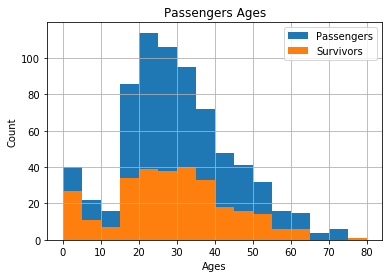

```python
#change age values from float to int

total_ages_frame['Age'] = total_ages_frame['Age'].astype(int)
surviving_ages_frame['Age'] = surviving_ages_frame['Age'].astype(int)
#This code produces a warning which setting errors='ignore' doesn't stop. Seem to be getting correct result so ignoring.


#plot histogram
'''Note - the histogram uses 16 bins to be more readable.  This is technically plotting different data to what is
described afterwards, but the error margins should be small.'''
total_ages_plot = total_ages_frame['Age'].hist(bins=16)
total_ages_plot.set_title("Passengers Ages")
total_ages_plot.set_xlabel("Ages")
total_ages_plot.set_ylabel("Count")
total_ages_plot.legend(["Passengers", "Survivors"])


surviving_ages_plot = surviving_ages_frame['Age'].hist(bins=16)
surviving_ages_plot.legend(["Passengers", "Survivors"])
```

As expected, this doesn't really tell me much and was done mostly as an excercise. Both follow the same general shape, so age doesn't seem to have been a factor in survivorship ratios. The '15-19' bin does show a drop off in the survival rate compared to the previous bins, which might support a case for dropping the adult age above. The '20-24' bin also has a slightly lower survival rate than most of the adult population. I wouldn't be surprised if this ties in with passenger class (i.e. more passengers in this age group in 3rd class), but this is well within one standard deviation of the mean and this project is already overdue so I'm not going to investigate this further. We can also note a slight dip in the ratios for the '40-44' and '45-49' bins. Again, these are well within one standard deviation of the mean so I'm not going to investigate further.

We can also note that the number of survivors above the age of 65 drops to near zero, but this could probably have been expected as well. Two bins ('65-69' and '70-74') have a 0% survival rate, but the numbers in these bins are small. Because these are 0% it's pointless to do any statistal tests on them, but if we were actually looking for interesting data points to investigate passenger safetly, this might be a place to start looking to make improvements. It's probably more surprising that the one 80 year old passenger survived. I wonder if he received an extrodinary level of care?

```python
#Hardcoding bin size as 5 and number as 17 for simplicity because dataset is small and fixed.

bins = [0, 4, 9, 14, 19, 24, 29, 34, 39, 44, 49, 54, 59, 64, 69, 74, 79, 84]

bin_names = ['0-4', '5-9', '10-14', '15-19', '20-24', '25-29', '30-34', '35-39', '40-44', '45-49', '50-54', '55-59',
             '60-64', '65-69', '70-74', '75-79', '80-84']


def make_bins(my_dataframe):

    bins_series = pd.cut(my_dataframe['Age'], bins, labels=bin_names)

    return bins_series

passenger_ages_series = pd.Series(make_bins(total_ages_frame))
print (pd.value_counts(passenger_ages_series))
survivor_ages_series = pd.Series(make_bins(surviving_ages_frame))
print (pd.value_counts(survivor_ages_series))
```

```
20-24    114
25-29    106
30-34     95
15-19     86
35-39     72
40-44     48
45-49     41
0-4       33
50-54     32
5-9       22
55-59     16
10-14     16
60-64     15
70-74      6
65-69      4
80-84      1
75-79      0
Name: Age, dtype: int64
30-34    40
20-24    39
25-29    38
15-19    34
35-39    33
0-4      20
40-44    18
45-49    16
50-54    14
5-9      11
10-14     7
55-59     6
60-64     6
80-84     1
75-79     0
65-69     0
70-74     0
Name: Age, dtype: int64
```

At this point, I'm wondering what the data would look like if we combined questions 1 and 2? I'll include this in the write up and append it as an additional question.

Note : I'm still working with the sample dataframes that have age attributes.

```
       Overall  Men  Women  Children
Total      891  395    206       113
1st        186   36     75        11
2nd        173    6     56        21
3rd        355   28     28        29
```

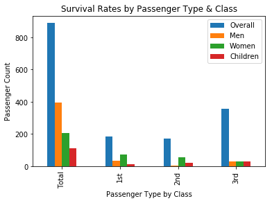

```python
#Create the dataframes
'''This is going against my earlier wish about not wanting to create too many dataframes despite the small size of
the total data set.  The way my code is set up it makes sense to create new frames and use existing functions.  If
the dataset was large or I was going to be running this code a lot, the optimum solution would probably be to go
back and combine the count_classes and count_types functions, and just cycle through the data once.
'''

first_class_pass_with_age = passengers_with_age[passengers_with_age['Pclass'] == 1]
second_class_pass_with_age = passengers_with_age[passengers_with_age['Pclass'] == 2]
third_class_pass_with_age = passengers_with_age[passengers_with_age['Pclass'] == 3]

first_class_surv_with_age = survivors_with_age[survivors_with_age['Pclass'] == 1]
second_class_surv_with_age = survivors_with_age[survivors_with_age['Pclass'] == 2]
third_class_surv_with_age = survivors_with_age[survivors_with_age['Pclass'] == 3]

#Get the counts of surviving men women and children for each


surv_male_count_first, surv_female_count_first, surv_child_count_first = count_types(first_class_surv_with_age)
surv_male_count_second, surv_female_count_second, surv_child_count_second = count_types(second_class_surv_with_age)
surv_male_count_third, surv_female_count_third, surv_child_count_third = count_types(third_class_surv_with_age)

#Plot the graph.


class_type_dict = {'Overall' : pd.Series([891, len(first_class_pass_with_age), len(second_class_pass_with_age), len(third_class_pass_with_age)], index = ['Total', '1st', '2nd', '3rd']),
               'Men' : pd.Series([total_male_count, surv_male_count_first, surv_male_count_second, surv_male_count_third], index = ['Total', '1st', '2nd', '3rd']),
               'Women' : pd.Series([total_female_count, surv_female_count_first, surv_female_count_second, surv_female_count_third], index =['Total', '1st', '2nd', '3rd']),
               'Children' : pd.Series([total_child_count, surv_child_count_first, surv_child_count_second, surv_child_count_third], index = ['Total', '1st', '2nd', '3rd'])}

class_type_frame = pd.DataFrame(class_type_dict, columns = ['Overall', 'Men', 'Women', 'Children'])

print class_type_frame
class_type_plot = class_type_frame.plot.bar(title='Survival Rates by Passenger Type & Class');
class_type_plot.set_xlabel("Passenger Type by Class")
class_type_plot.set_ylabel("Passenger Count")
```

This isn't very readable. I'm going to try leaving out the 'Overall' numbers of passengers in each class.

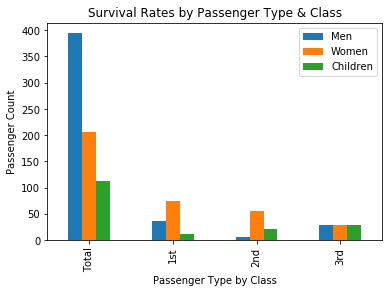

```python
n_class_type_dict = {'Men' : pd.Series([total_male_count, surv_male_count_first, surv_male_count_second, surv_male_count_third], index = ['Total', '1st', '2nd', '3rd']),
               'Women' : pd.Series([total_female_count, surv_female_count_first, surv_female_count_second, surv_female_count_third], index =['Total', '1st', '2nd', '3rd']),
               'Children' : pd.Series([total_child_count, surv_child_count_first, surv_child_count_second, surv_child_count_third], index = ['Total', '1st', '2nd', '3rd'])}

n_class_type_frame = pd.DataFrame(n_class_type_dict, columns = ['Men', 'Women', 'Children'])

n_class_type_plot = n_class_type_frame.plot.bar(title='Survival Rates by Passenger Type & Class');
n_class_type_plot.set_xlabel("Passenger Type by Class")
n_class_type_plot.set_ylabel("Passenger Count")
```

With the last chart above it's easier to see a few numbers that seem surprising. The number of surviving men in 2nd class is really low; just 6. This is out of 184 second class passengers (with or without age attributes), 88 of whom we know to be adult males.

Another number that seemed surprising is the low number of 1st class children that survived, given the survivorship ratio for children. It turns out that we can only identify 12 passengers in first class as children, so 11 survivors is actually pretty high.

It also seems strange that the numbers of survivors (with age attributes) in third class are about equal for men, women and children. When we look at the total numbers of men, women and children (with age attributes), the ratios while low, seem to be about what we expect given the lower survivorship ratio in third class. It can be noted that the percentage of surviving children in third class (~37%) is more than 50% lower than first or second class.

In summary, the survival rate of 2nd class male passengers seems to be an annomaly. For whatever reason, 2nd class male passengers had an exceptionally low survival rate.

```python
pass_male_count_first, pass_female_count_first, pass_child_count_first = count_types(first_class_pass_with_age)
print 'Number of male passengers in first class :', pass_male_count_first
print 'Number of female passengers in first class :', pass_female_count_first
print 'Number of children in first class :', pass_child_count_first
pass_male_count_second, pass_female_count_second, pass_child_count_second = count_types(second_class_pass_with_age)
print 'Number of male passengers in second class :', pass_male_count_second
print 'Number of female passengers in second class :', pass_female_count_second
print 'Number of children in second class :', pass_child_count_second
pass_male_count_third, pass_female_count_third, pass_child_count_third = count_types(third_class_pass_with_age)
print 'Number of male passengers in third class :', pass_male_count_third
print 'Number of female passengers in third class :', pass_female_count_third
print 'Number of children in third class :', pass_child_count_third
```

```
Number of male passengers in first class : 97
Number of female passengers in first class : 77
Number of children in first class : 12
Number of male passengers in second class : 88
Number of female passengers in second class : 62
Number of children in second class : 23
Number of male passengers in third class : 210
Number of female passengers in third class : 67
Number of children in third class : 78
```

Future task list :

- Calculate chi-square values manually for each question.
- Rewrite and combine count_classes and count_types functions.
- Investigate creating dataframes for plotting earlier and see if code is still readable.
- Try to remove error messages from histogram plot.